# Study Verification Test (SSP) Results

The study verification test (SSP) was conducted 15th of September 2017 for 1 hour on all MED1 student, in Aalborg at 9 am and in Copenhagen at 12:30 am. The immediate result of the test showed that a few students (around 7) did not show for the test, as they had dropped out in MED1. These dropouts will be replaced with new students. All active students took the test as requested.

The goals of analysing SSP:

1. Detecting students with high risk of dropping out. We will inform the student counselors who is the high-risk dropout students so they can take action. The student counselors need the results from SSP as an overview for each high-risk dropout students, e.g. a percentile rank for each category as in https://www.ruffalonl.com/complete-enrollment-management/student-success/rnl-retention-management-system-plus/samples.
2. Creating a tool for predicting dropouts (low priority).

TODOS:

- Compute different types of data analysis to describe the dropout rate (with aggegation of variables)
- Mail merge: https://www.r-bloggers.com/mail-merge-with-rmarkdown/
- Import remaining data from Moodle of the newcoming students?

This markdown script imports, cleans, and analyses the data from SSP.

### Importing and Cleaning Data

Setting the working directory to the SVN folder.

```r
SVNData<-if(grepl("BiancaClavio", getwd())){
  'C:/Users/BiancaClavio/Documents/SVN/01Projects/SSP/'} else {"~/SVN/01Projects/SSP/"}
setwd(SVNData)
```

```r
dfQAGrades<-read.csv("QuestionsOverview.csv",
  header = TRUE, fill=TRUE, sep = ",", check.names=FALSE)
```

Importing SSP grades and answers via Moodle in Aalborg and Copenhagen. All text strings for the grading attributes are converted to NA’s, e.g. Moodle write “-” when a student skipped a question. The data analysis further down ignores NA’s in the computations.

```r
dfSSPgradesCPH<-read.csv("SSPgradesTestCPH 02-10.csv",
  header = TRUE, fill=TRUE, sep = ",", check.names=FALSE)
dfSSPgradesAAL<-read.csv("SSPgradesTestAAL 02-10.csv",
  header = TRUE, fill=TRUE, sep = ",", check.names=FALSE)
dfSSPanswersCPH<-read.csv("SSPanswersTestCPH 28-09.csv",
  header = TRUE, fill=TRUE, sep = ",", check.names=FALSE)
dfSSPanswersAAL<-read.csv("SSPanswersTestAAL 28-09.csv",
  header = TRUE, fill=TRUE, sep = ",", check.names=FALSE)
```

```r
dfSSPanswersAAL[35:43] <- apply(dfSSPanswersAAL[35:43],2, function(dfSSPanswersAAL)
  gsub("No influence","Not at all true",dfSSPanswersAAL))
dfSSPanswersAAL[35:43] <- apply(dfSSPanswersAAL[35:43],2, function(dfSSPanswersAAL)
  gsub("Limited influence","Slightly true",dfSSPanswersAAL))
dfSSPanswersAAL[35:43] <- apply(dfSSPanswersAAL[35:43],2, function(dfSSPanswersAAL)
  gsub("Some influence","Some influence",dfSSPanswersAAL))
dfSSPanswersAAL[35:43] <- apply(dfSSPanswersAAL[35:43],2, function(dfSSPanswersAAL)
  gsub("Decisive influence","Completely true",dfSSPanswersAAL))
```

Adds the campus variable:

```r
dfSSPgradesCPH["Campus"]<-"CPH"
dfSSPgradesAAL["Campus"]<-"AAL"
dfSSPanswersCPH["Campus"]<-"CPH"
dfSSPanswersAAL["Campus"]<-"AAL"
```

Removes the last row for the dataset with grades (called overall).

```r
dfSSPgradesAAL <- dfSSPgradesAAL[-nrow(dfSSPgradesAAL),]
dfSSPgradesCPH <- dfSSPgradesCPH[-nrow(dfSSPgradesCPH),]
```

Combines data from AAL and CPH. The two variables should have the same number of observations, otherwise something went wrong in the previous steps.

```r
names(dfSSPgradesAAL) <- names(dfSSPgradesCPH) # debugging: weird column names
```

```
Error in names(dfSSPgradesAAL) <- names(dfSSPgradesCPH) :
  'names' attribute [122] must be the same length as the vector [2]
```

Combines Surname with First name

```r
dfSSPgrades["Name"] <- paste(dfSSPgrades$'First name', dfSSPgrades$Surname)
dfSSPanswers["Name"] <- paste(dfSSPanswers$'First name', dfSSPanswers$Surname)
```

Replaces all values with NA for questions about study/working hours:

```r
dfSSPgrades$Q..93..0.09 <- NA
dfSSPgrades$Q..95..0.09 <- NA
dfSSPgrades$Q..96..0.09 <- NA
```

Removes outliers that did not complete the quiz (in this case it was a teacher who tried the test)

```r
dfSSPgrades <- dfSSPgrades[!grepl("In progress", dfSSPgrades$State),]
```

Replaces skipped questions with zero:

```r
dfSSPgrades <- data.frame(lapply(dfSSPgrades, function(x) { gsub("-", 0, x) }))
```

### Data Analysis

```r
dfSSPgradesStat <- data.frame( lapply(dfSSPgrades[7:117], function(x) as.numeric(as.character(x))) )
#dfSSPgradesStat["rowID"] <- seq(1:nrow(dfSSPgradesStat))
dfSSPgradesStat["Mean"] <- rowMeans(dfSSPgradesStat[1:4], na.rm=TRUE)
```

#### Overview of SSP Dataset

Plotting a histogram with normal curve (blue) and the distribution (red) of the average grades:

```r
x <- dfSSPgradesStat$Mean
h<-hist(x, breaks=(nrow(dfSSPgradesStat))/10, col="grey", xlab="Average Grade",
  main="Histogram of Average Grades", xlim=c((min(dfSSPgradesStat$Mean)-0.02),
  (max(dfSSPgradesStat$Mean)+0.02)), ylim=c(0,50))
xfit<-seq(min(x),max(x),length=40)
yfit<-dnorm(xfit,mean=mean(x),sd=sd(x))
yfit <- yfit*diff(h$mids[1:2])*length(x)
lines(xfit, yfit, col="darkblue", lwd=2)
```

[figure not shown]

```r
rug(dfSSPgradesStat$Mean,col="blue")
points(density(dfSSPgradesStat$Mean),type="l",col="red", lwd=2)
```

Descriptive statistics of average grade (including variables (vars), number of valid cases (n), mean, standard deviation (sd), median, trimmed, median absolute deviation (mad), minimum (min), maximum (max), skew, kurtosis, standard error (se)):

```r
#summary(dfSSPgradesStat$Mean)
kable(describe(dfSSPgradesStat$Mean), digits=2)
```

|  | vars | n | mean | sd | median | trimmed | mad | min | max | range | skew | kurtosis | se |
| --- | --- | --- | --- | --- | --- | --- | --- | --- | --- | --- | --- | --- | --- |
| X1 | 1 | 190 | 0.05 | 0.01 | 0.04 | 0.05 | 0.01 | 0.02 | 0.08 | 0.06 | 0.38 | 0.07 | 0 |

QQ-plot of the average grades:

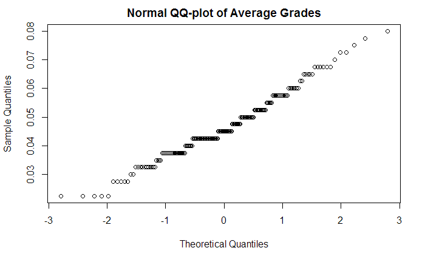

```r
qqnorm(dfSSPgradesStat$Mean, main="Normal QQ-plot of Average Grades")
```

```r
x <- dfSSPgrades$Grade.10.00
h<-hist(x, breaks=(190/10), col="grey", xlab="Moodle Grade", main="Histogram of Moodle Grades",
  ylim=c(0,40), xlim=c((min(dfSSPgrades$Grade.10.00)-0.8), (max(dfSSPgrades$Grade.10.00)+0.8)))
xfit<-seq(min(x),max(x),length=40)
yfit <-dnorm(xfit,mean=mean(x),sd=sd(x))
yfit <- yfit*diff(h$mids[1:2])*length(x)
lines(xfit, yfit, col="darkblue", lwd=2)
rug(dfSSPgrades$`Grade/10.00`,col="blue")
#points(density(dfSSPgrades$`Grade/10.00`),type="l",col="red")
```

[output not shown]

Descriptive statistics of average grade(including variables (vars), number of valid cases (n), mean, standard deviation (sd), median, trimmed, median absolute deviation (mad), minimum (min), maximum (max), skew, kurtosis, standard error (se)):

```r
#summary(dfSSPgrades$`Grade/10.00`)
kable(describe(dfSSPgrades$Grade.10.00), digits=2)
```

[output not shown]

```r
qqnorm(dfSSPgrades$Grade.10.00, main="Normal QQ-plot of Moodle Grades")
```

[output not shown]

#### Individual Student

Creates a new dataset for manipulating data of the individual student:

```r
dfSSPgradesStat1 <- dfSSPgradesStat
#dfSSPgradesStat1['Name'] <- dfSSPgrades$Name
dfSSPgradesStat1 <- dfSSPgradesStat1[, -c(112)]
```

Categorizing each question:

```r
dfSSPgradesStat1 <- rbind(dfSSPgradesStat1, "Category")

dfSSPgradesStat1[1:9] <- apply(dfSSPgradesStat1[1:9],2, function(dfSSPgradesStat1)
  gsub("Category", "Demographics",dfSSPgradesStat1))
dfSSPgradesStat1[10:15] <- apply(dfSSPgradesStat1[10:15],2, function(dfSSPgradesStat1)
  gsub("Category", "Attitude.Towards.Education",dfSSPgradesStat1))
dfSSPgradesStat1[16:23] <- apply(dfSSPgradesStat1[1:9],2, function(dfSSPgradesStat1)
  gsub("Category", "Reasons.for.Going.to.University",dfSSPgradesStat1))
dfSSPgradesStat1[24:33] <- apply(dfSSPgradesStat1[24:33],2, function(dfSSPgradesStat1)
  gsub("Category", "Education.Choice.Factors",dfSSPgradesStat1))
dfSSPgradesStat1[34:45] <- apply(dfSSPgradesStat1[34:45],2, function(dfSSPgradesStat1)
  gsub("Category", "High.School.Behaviour",dfSSPgradesStat1))
dfSSPgradesStat1[46:50] <- apply(dfSSPgradesStat1[46:50],2, function(dfSSPgradesStat1)
  gsub("Category", "High.School.Trust",dfSSPgradesStat1))
dfSSPgradesStat1[51:56] <- apply(dfSSPgradesStat1[51:56],2, function(dfSSPgradesStat1)
  gsub("Category", "Belonging.Uncertainty",dfSSPgradesStat1))
dfSSPgradesStat1[57:61] <- apply(dfSSPgradesStat1[57:61],2, function(dfSSPgradesStat1)
  gsub("Category", "Grit",dfSSPgradesStat1))
dfSSPgradesStat1[62:64] <- apply(dfSSPgradesStat1[62:64],2, function(dfSSPgradesStat1)
  gsub("Category", "Growth.Mindset",dfSSPgradesStat1))
dfSSPgradesStat1[65:74] <- apply(dfSSPgradesStat1[65:74],2, function(dfSSPgradesStat1)
  gsub("Category", "Self-control",dfSSPgradesStat1))
dfSSPgradesStat1[75:87] <- apply(dfSSPgradesStat1[75:87],2, function(dfSSPgradesStat1)
  gsub("Category", "Personal.Trait.Comparison",dfSSPgradesStat1))
dfSSPgradesStat1[88:92] <- apply(dfSSPgradesStat1[88:92],2, function(dfSSPgradesStat1)
  gsub("Category", "Perceived.Academic.Abilities",dfSSPgradesStat1))
dfSSPgradesStat1[93:97] <- apply(dfSSPgradesStat1[93:97],2, function(dfSSPgradesStat1)
  gsub("Category", "Studying-Working.Hours",dfSSPgradesStat1))
dfSSPgradesStat1[98:111] <- apply(dfSSPgradesStat1[98:111],2, function(dfSSPgradesStat1)
  gsub("Category", "View.on.Medialogy",dfSSPgradesStat1))
```

Computes the percentages of a student’s answer for each question:

```r
dfSSPgradesStat2 <- prop.table(as.matrix(dfSSPgradesStat), margin=2)*100
```

TODO: change this code into something useful:

```r
percGrades <- within(percGrades, xr <- perc.rank(dfSSPgradesStat$Q..1..0.09)*100)
```

```
Error in UseMethod("within") :
  no applicable method for 'within' applied to an object of class "c('double', 'numeric')"
```

TODO: Individual summary compared to the cohort.

```r
write.csv(percGrades,file = "SSPgrades.csv")
```